# Data Analysis Project

Hypothesis: H0 The 5 groups are equal in terms of age H1 At least one group is different from the other 4 groups in terms of age.

```r
oneway.test(agea ~ cptppola, data = ESS_anova, var.equal = T)
```

```
##
##  One-way analysis of means
##
## data:  agea and cptppola
## F = 3.498, num df = 4, denom df = 1537, p-value = 0.007497
```

There is a significant difference between some of the groups, as p-value is lower than 0.05, and we reject null hypothesis.

```r
model<-lm(agea ~ cptppola, data = ESS_anova)
model
```

```
##
## Call:
## lm(formula = agea ~ cptppola, data = ESS_anova)
##
## Coefficients:
##                  (Intercept)    cptppolaA little confident
##                       55.740                        -3.601
##      cptppolaQuite confident        cptppolaVery confident
##                       -3.474                        -4.246
## cptppolaCompletely confident
##                       -2.675
```

```r
shapiro_test(residuals(model))
```

```
## # A tibble: 1 × 3
##   variable         statistic  p.value
##   <chr>                <dbl>    <dbl>
## 1 residuals(model)     0.986 5.99e-11
```

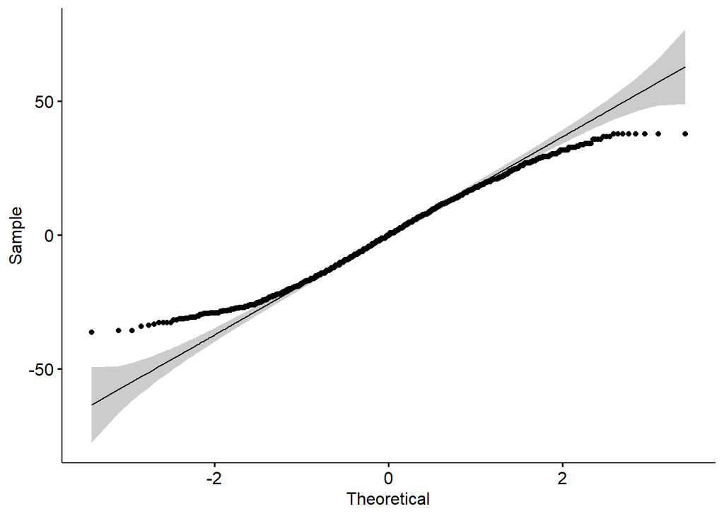

```r
ggqqplot(residuals(model))
```

However, after performing Shapiro test for residual, we see that they are no distributed normally, so results of oneway.test are not representative and we need to use non-parametric test-Kruskal- Wallis ANOVA test.

Hypothesis: H0 The 5 groups are equal in terms of age H1 At least one group is different from the other 4 groups in terms of age.

```r
kruskal.test(agea ~ cptppola, data = ESS_anova)
```

```
##
##  Kruskal-Wallis rank sum test
##
## data:  agea by cptppola
## Kruskal-Wallis chi-squared = 12.891, df = 4, p-value = 0.01182
```

P-value is less than the significance level 0.05, we can conclude that there is a significant difference in age between groups with different level of confidence in their ability to participate in politics, so we reject null hypothesis.

Post-hoc test for Kruskal-Wallis is a Dunn’s test. We will also use method of Bonferroni as we have 5 groups to lower the chance of getting random significant difference. Through the bonferroni correction our significance level is 0,05/10=0,005, where 10 is our total amount of pairs and 0,05 is previous significance level.

```r
dunnTest(ESS_anova$agea ~ ESS_anova$cptppola,data = ESS_anova, method = "bonferroni")
```

```
##                                     Comparison          Z      P.unadj
## 1    A little confident - Completely confident -0.4464973 0.6552380833
## 2    A little confident - Not at all confident -3.2952045 0.0009835008
## 3  Completely confident - Not at all confident -0.9365282 0.3490013091
## 4         A little confident - Quite confident -0.2073592 0.8357293656
## 5       Completely confident - Quite confident  0.3557736 0.7220101420
## 6       Not at all confident - Quite confident  2.8789630 0.0039898519
## 7          A little confident - Very confident  0.1423779 0.8867815018
## 8        Completely confident - Very confident  0.4603187 0.6452874962
## 9        Not at all confident - Very confident  1.8757945 0.0606835005
## 10            Quite confident - Very confident  0.2464781 0.8053121448
##          P.adj
## 1  1.000000000
## 2  0.009835008
## 3  1.000000000
## 4  1.000000000
## 5  1.000000000
## 6  0.039898519
## 7  1.000000000
## 8  1.000000000
## 9  0.606835005
## 10 1.000000000
```

p-value is in the last column

We can see that there is a significant difference in age between 2 groups: “A little confident- Not at all confident” and “Not at all confident - Quite confident”. The rest pairs of groups of people with different levels of political interest have not statistically significant differences in means.

```r
kruskal_effsize(ESS_anova, agea ~ cptppola)
```

```
## # A tibble: 1 × 5
##   .y.       n effsize method  magnitude
## * <chr> <int>   <dbl> <chr>   <ord>
## 1 agea   1542 0.00578 eta2[H] small
```

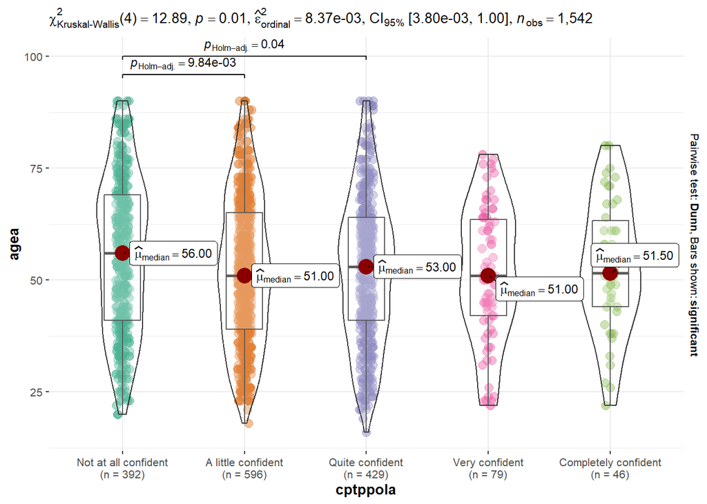

```r
ggbetweenstats(ESS_anova, x=cptppola, y=agea,
               plot.type="box",
               type = "nonparametric")
```

This plot shows visually where we have the biggest difference and how some groups differ from others.

## Overall conclusion:

Based on studying the data and conducting a series of tests, we came to the following conclusions:

1. The opinions of French citizens about their ability to play an active role in a political group are quite closely related to gender. Among those who are not capable at all, there are many more women than men and vice versa.
2. One of the important factors influencing voting behavior in France is age. Despite reaching the age of majority, young citizens practically do not attend elections, on the other hand, people over fifty for the most part regularly attend elections.
3. Despite the fact that French citizens who are over fifty years old, for the most part, regularly attend elections and do so more often than younger citizens, their confidence in their own ability to participate in politics is less than that of younger ones.

To sum up, according to the results of our tests, our drawing reflects and once again confirms the judgments of the research interest.

# Project 3

Research interest: In this project we aim to explore how trust in politicians and level of political inclusiveness allowed by government perceived by people are correlated with levels of satisfaction of French citizens with the national government. Firstly, trust in politicians is essential for the legitimacy of government and public satisfaction with its work. In France, this trust can be especially unstable, influenced by ongoing political changes and public perceptions of politicians’ credibility. Misheler and Rose in their study have shown that trust in political actors directly influences public perceptions of governmental efficacy, which is why we believe to be a significant component of our project interest(Mishler and Rose, 2011). Secondly, we believe perceptions of political inclusiveness, or the extent to which citizens feel they can influence government decisions, how included they feel in political decision-making, to be crucial for public satisfaction with national government. In France, active public involvement and protests are more common, which highlights the importance of understanding how these perceptions impact public satisfaction. When citizens perceive their political system as inclusive, allowing them to have a say in governmental decisions, their satisfaction with the government typically increases (Soroka and Wlezien, 2010). References: Mishler, W., & Rose, R. (2011). What are the origins of political trust?: Testing institutional and cultural theories in post-communist societies. Comparative Political Studies, 34(1), 30-62. Soroka, S., & Wlezien, C. (2010). Degrees of Democracy: Politics, Public Opinion, and Policy. Cambridge University Press.

Research question: How do trust in politicians, age and perceptions of political inclusiveness impact public satisfaction with the national government among French citizens?

Hypotheses: 1.Higher levels of trust in politicians are associated with greater satisfaction with the national government among French citizens. 2.Higher perceived political inclusiveness is associated with higher satisfaction with the national government among French citizens. 3.Higher age of respondent is associated with greater satisfaction with the national government among French citizens.

Justification of variables’ choice: Trust in Politicians (trstplt): this variable is critical as it reflects how reliable and trustworthy French politicians are, which reflects our outcome: how satisfied are people with national governance particularly in a French context where political trust can be unstable and change to a large extent. Perceived Political Inclusiveness (psppsgva): this varible estimates to what extent the political system incorporates public opinion of citizens into decision-making processes,basically how much they feel included and capable to have a say in politics, which we assume would as well impact public’s satisfaction with the national government

## Preparing data for analysis:

We will use not only trust in politicians and age, but also trust in legal system and trust in policies as they can be similar to trust in politicians and can have more effect on satisfaction.

```r
ESS3 = ESS %>%
  dplyr::select(stfgov, trstplt, psppsgva, trstlgl, trstplc, agea)%>%
  na.omit()

ESS3 = ESS3 %>%
  filter(stfgov != 77) %>%
  filter(stfgov != 88) %>%
  filter(stfgov != 99)

ESS3 = ESS3 %>%
  filter(trstplt != 77) %>%
  filter(trstplt != 88) %>%
  filter(trstplt != 99)

ESS3 = ESS3 %>%
  filter(trstlgl != 77) %>%
  filter(trstlgl != 88) %>%
  filter(trstlgl != 99)

ESS3 = ESS3 %>%
  filter(trstplc != 77) %>%
  filter(trstplc != 88) %>%
  filter(trstplc != 99)

ESS3 = ESS3 %>%
  filter(agea != 999)

ESS3 = ESS3 %>%
  filter(psppsgva != 7) %>%
  filter(psppsgva != 8) %>%
  filter(psppsgva != 9)
```

## Manipulating & Describing variables:

```r
Label3 <- c("`stfgov`", "`trstplt`", "`psppsgva`", "`trstlgl`", "`trstplc`", "`agea`")
Meaning3 <- c("How satisfied with the national government", "Trust in politicians", "Political system allows people to have a say in what government does", "Trust in legal system", "Trust in policies", "Age")
Level_Of_Measurement3 <- c("Quasi-interval (as numeric)", "Quasi-interval (as numeric)", "Ordinal", "Quasi-interval (as numeric)", "Quasi-interval (as numeric)", "Inteval")
Measurement3 <- c("0 - 10", "0 - 10", "Not at all - Very little - Some - A lot - A great deal", "0 - 10", "0 - 10", "16-90")
df3 <- data.frame(Label3, Meaning3, Level_Of_Measurement3, Measurement3, stringsAsFactors = FALSE)
kable(df3) %>%
  kable_styling(bootstrap_options=c("bordered", "responsive","striped"), full_width = FALSE)
```

| Label3 | Meaning3 | Level_Of_Measurement3 | Measurement3 |
| --- | --- | --- | --- |
| `stfgov` | How satisfied with the national government | Quasi-interval (as numeric) | 0 - 10 |
| `trstplt` | Trust in politicians | Quasi-interval (as numeric) | 0 - 10 |
| `psppsgva` | Political system allows people to have a say in what government does | Ordinal | Not at all - Very little - Some - A lot - A great deal |
| `trstlgl` | Trust in legal system | Quasi-interval (as numeric) | 0 - 10 |
| `trstplc` | Trust in policies | Quasi-interval (as numeric) | 0 - 10 |
| `agea` | Age | Inteval | 16-90 |

Let’s recode all variables to correct type:

```r
ESS3$stfgov <-  as.numeric(as.character(ESS3$stfgov))
ESS3$trstplt <-  as.numeric(as.character(ESS3$trstplt))
ESS3$trstplc <-  as.numeric(as.character(ESS3$trstplc))
ESS3$trstlgl <-  as.numeric(as.character(ESS3$trstlgl))
ESS3$agea <-  as.numeric(as.character(ESS3$agea))
ESS3$psppsgva <-  as.numeric(as.character(ESS3$psppsgva))
```

P.S Firstly, we recode psppsgva to numeric. We will speak about it later.

## Descriptive statistics for numeric variables:

```r
v.stfgov <- c(mean(ESS3$stfgov), Mode(ESS3$stfgov), median(ESS3$stfgov), sd(ESS3$stfgov), min(ESS3$stfgov), max(ESS3$stfgov))
names(v.stfgov) <- c("mean", "mode", "median", "sd", "min", "max")

v.trstplt <- c(mean(ESS3$trstplt), Mode(ESS3$trstplt), median(ESS3$trstplt), sd(ESS3$trstplt), min(ESS3$trstplt), max(ESS3$trstplt))
names(v.trstplt) <- c("mean", "mode", "median", "sd", "min", "max")

v.trstplc <- c(mean(ESS3$trstplc), Mode(ESS3$trstplc), median(ESS3$trstplc), sd(ESS3$trstplc), min(ESS3$trstplc), max(ESS3$trstplc))
names(v.trstplc) <- c("mean", "mode", "median", "sd", "min", "max")

v.trstlgl <- c(mean(ESS3$trstlgl), Mode(ESS3$trstlgl), median(ESS3$trstlgl), sd(ESS3$trstlgl), min(ESS3$trstlgl), max(ESS3$trstlgl))
names(v.trstlgl) <- c("mean", "mode", "median", "sd", "min", "max")

v.agea <- c(mean(ESS3$agea), Mode(ESS3$agea), median(ESS3$agea), sd(ESS3$agea), min(ESS3$agea), max(ESS3$agea))
names(v.agea) <- c("mean", "mode", "median", "sd", "min", "max")

tendencymeasures_overview_num =  data.frame(v.stfgov, v.trstplt, v.trstplc, v.trstlgl, v.agea, stringsAsFactors = FALSE)

kable(tendencymeasures_overview_num) %>%
  kable_styling(bootstrap_options=c("bordered", "responsive","striped"), full_width = FALSE)
```

|  | v.stfgov | v.trstplt | v.trstplc | v.trstlgl | v.agea |
| --- | --- | --- | --- | --- | --- |
| mean | 4.726108 | 3.884677 | 6.333155 | 5.195408 | 49.55793 |
| mode | 5.000000 | 5.000000 | 7.000000 | 5.000000 | 53.00000 |
| median | 5.000000 | 4.000000 | 7.000000 | 5.000000 | 50.00000 |
| sd | 2.292977 | 2.170004 | 2.151340 | 2.451068 | 18.50979 |
| min | 0.000000 | 0.000000 | 0.000000 | 0.000000 | 16.00000 |
| max | 10.000000 | 10.000000 | 10.000000 | 10.000000 | 90.00000 |

We can see that the highest mean (6,3) and median (7) is in trust in policies. As it quasi-interval there is minimum 0 in all variablea and maximum 10 in all variables. The mean age is 49, minimum - 16, maximum 90.

## Descriptive statistics for categorical variable:

```r
table(ESS3$psppsgva)
```

```
##
##   1   2   3   4   5
## 463 655 601 131  23
```

```r
ESS3 = ESS3 %>%
  mutate(psppsgva = case_when(
    psppsgva %in% 4:5 ~ 4,
    TRUE ~ as.numeric(psppsgva)
  ))
ESS3$psppsgva <- factor(ESS3$psppsgva, labels = c("Not at all", "Very little", "Some", "A lot"), ordered = F)
table(ESS3$psppsgva)
```

```
##
##  Not at all Very little        Some       A lot
##         463         655         601         154
```

Now we can see that we have 4 categories. Category “A lot” was mentioned by 154.

Now we will show our variables graphically.

For that we will need to create:

Box plot, to show the categorical variables.

Density plot(Histogram), to check if the distribution of our continuous variables is close to normal.

1.Boxplot:

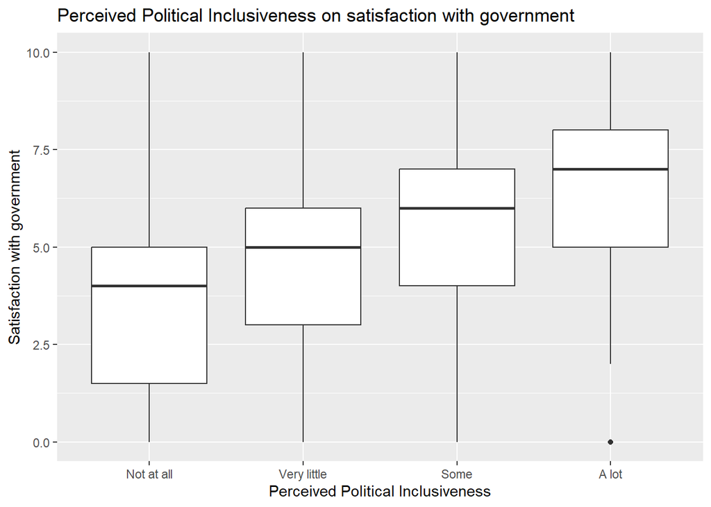

```r
ggplot(ESS3, aes(x = psppsgva,, y = stfgov)) +
  geom_boxplot() +
  labs(title = "Perceived Political Inclusiveness on satisfaction with government",
       x = "Perceived Political Inclusiveness",
       y = "Satisfaction with government")
```

Firstly, we can see one outlier who dissatisfied with national government and think that Political system a lot allows people to have a say in what government does. If people think that Political system a lot allows people to have a say in what government does than they have higher satisfaction with government.

2.Histograms:

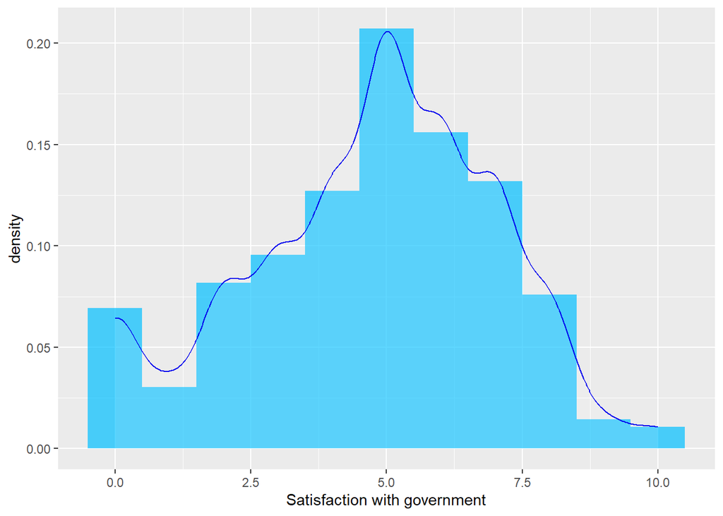

```r
ggplot(data = ESS3, aes(x = stfgov)) + geom_histogram(aes(y=..density..), position = "identity", alpha = 0.7, binwidth = 1, fill = "#00BFFF") + geom_density(col = "blue2", fill = "white", alpha = 0.1) + xlab("Satisfaction with government")
```

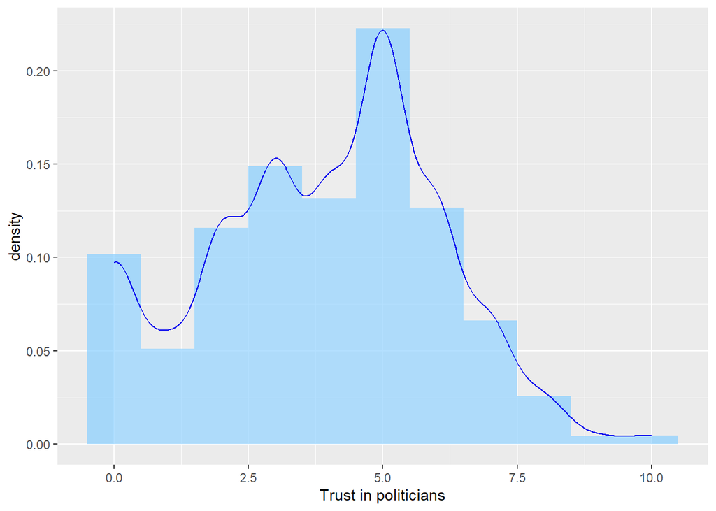

```r
ggplot(data = ESS3, aes(x = trstplt)) + geom_histogram(aes(y=..density..), position = "identity", alpha = 0.7, binwidth = 1, fill = "skyblue1") + geom_density(col = "blue2", fill = "white", alpha = 0.1) + xlab("Trust in politicians")
```

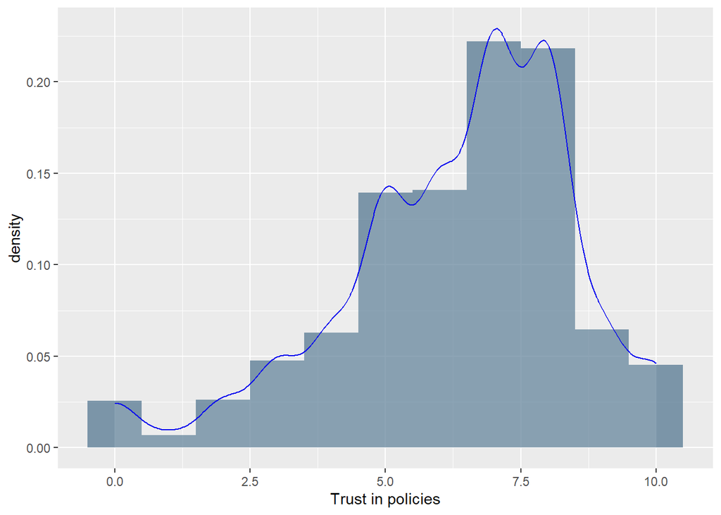

```r
ggplot(data = ESS3, aes(x = trstplc)) + geom_histogram(aes(y=..density..), position = "identity", alpha = 0.7, binwidth = 1, fill = "skyblue4") + geom_density(col = "blue2", fill = "white", alpha = 0.1) + xlab("Trust in policies")
```

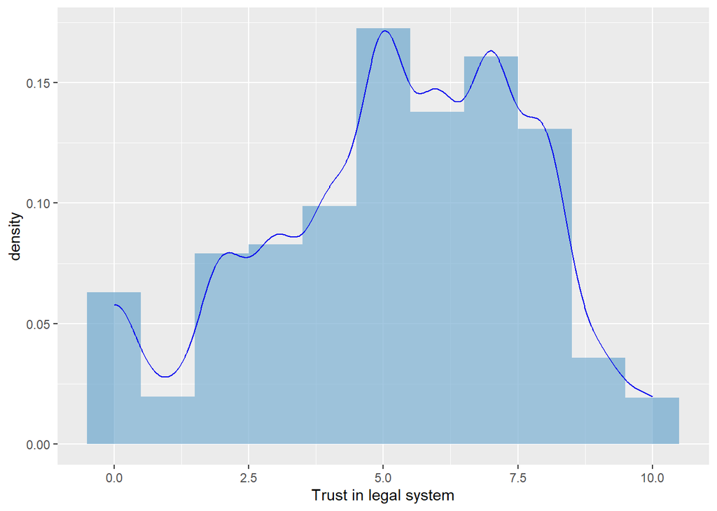

```r
ggplot(data = ESS3, aes(x = trstlgl)) + geom_histogram(aes(y=..density..), position = "identity", alpha = 0.7, binwidth = 1, fill = "skyblue3") + geom_density(col = "blue2", fill = "white", alpha = 0.1) + xlab("Trust in legal system")
```

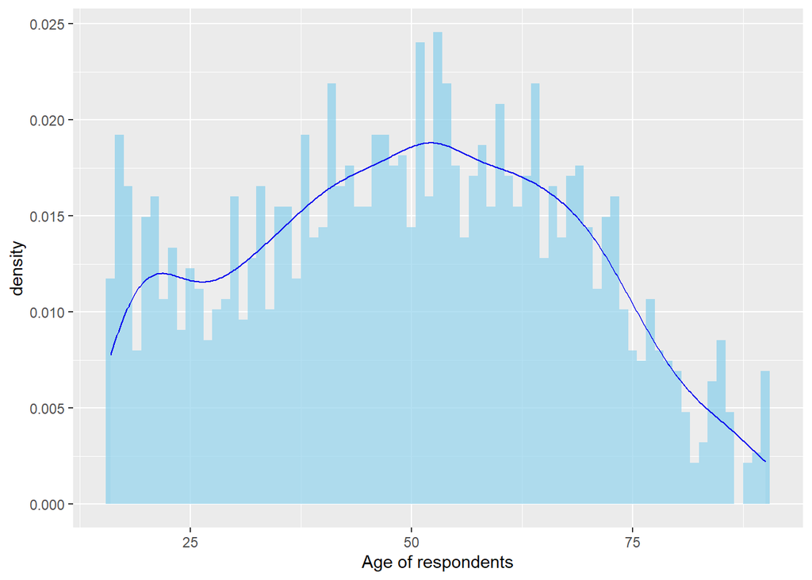

```r
ggplot(data = ESS3, aes(x = agea)) + geom_histogram(aes(y=..density..), position = "identity", alpha = 0.7, binwidth = 1, fill = "skyblue") + geom_density(col = "blue2", fill = "white", alpha = 0.1) + xlab("Age of respondents")
```

As it can be seen from the histograms, satisfaction with goverment is slightly close to normal distribution. But trust in politicians is slightly close to non normal distribution. Mostly people choose 5. Also, trust in policies is slightly close to non normal distribution. Mostly people choose 7. Also, trust in legal system is slightly close to non normal distribution. Mostly people choose 5. Also, age is slightly close to non normal distribution.

Let’s look at correlation coefficients: As we have non normal distributed data

```r
ESS = ESS3 %>%
  dplyr::select(trstplt,agea, stfgov, trstlgl, trstplc)
tab_corr(ESS, corr.method = "spearman")
```

|  | trstplt | agea | stfgov | trstlgl | trstplc |
| --- | --- | --- | --- | --- | --- |
| trstplt |  | 0.001 | 0.517*** | 0.491*** | 0.418*** |
| agea | 0.001 |  | 0.053* | -0.120*** | 0.072** |
| stfgov | 0.517*** | 0.053* |  | 0.398*** | 0.355*** |
| trstlgl | 0.491*** | -0.120*** | 0.398*** |  | 0.532*** |
| trstplc | 0.418*** | 0.072** | 0.355*** | 0.532*** |  |
| Computed correlation used spearman-method with listwise-deletion. |  |  |  |  |  |

We can see that trust in politicians and satisfaction with goverment has positive direction. (0,517) And it is the biggest among other variables. Also, age and trust in politicians don’t have effect on each other. Therefore, we can work with them in models. There is a very high level of significance*** (p <. 001) in trust in politicians and satisfaction with goverment. And there is a normal level of significance* in age and satisfaction with goverment.

## Hierarchically building models:

Lets first build model with a numeric quasi-interval predictor: trust in politicians.

```r
first_var<-lm(stfgov~trstplt,ESS3)
summary(first_var)
```

```
##
## Call:
## lm(formula = stfgov ~ trstplt, data = ESS3)
##
## Residuals:
##     Min      1Q  Median      3Q     Max
## -8.1648 -1.3533  0.0844  1.2090  7.4583
##
## Coefficients:
##             Estimate Std. Error t value Pr(>|t|)
## (Intercept)  2.54170    0.09202   27.62   <2e-16 ***
## trstplt      0.56231    0.02068   27.19   <2e-16 ***
## ---
## Signif. codes:  0 '***' 0.001 '**' 0.01 '*' 0.05 '.' 0.1 ' ' 1
##
## Residual standard error: 1.942 on 1871 degrees of freedom
## Multiple R-squared:  0.2832, Adjusted R-squared:  0.2828
## F-statistic: 739.2 on 1 and 1871 DF,  p-value: < 2.2e-16
```

To this numeric predictor, lets add another categorical predictor political system allows people to have a say in what government does and another umeric predictor age.

Additive model: Outcome - stfgov - How satisfied with the national government Predictictors: trstplt - Trust in politicians psppsgva - Political system allows people to have a say in what government does agea - age of respondents Code:

```r
ad_model<-lm(stfgov ~ trstplt + psppsgva + agea,data = ESS3)
summary(ad_model)
```

```
##
## Call:
## lm(formula = stfgov ~ trstplt + psppsgva + agea, data = ESS3)
##
## Residuals:
##     Min      1Q  Median      3Q     Max
## -7.8599 -1.2408  0.1128  1.2278  7.9230
##
## Coefficients:
##                     Estimate Std. Error t value Pr(>|t|)
## (Intercept)         1.961956   0.161947  12.115  < 2e-16 ***
## trstplt             0.484195   0.022487  21.532  < 2e-16 ***
## psppsgvaVery little 0.512675   0.119499   4.290 1.88e-05 ***
## psppsgvaSome        0.835384   0.128887   6.482 1.16e-10 ***
## psppsgvaA lot       1.448319   0.187712   7.716 1.95e-14 ***
## agea                0.006392   0.002393   2.671  0.00763 **
## ---
## Signif. codes:  0 '***' 0.001 '**' 0.01 '*' 0.05 '.' 0.1 ' ' 1
##
## Residual standard error: 1.906 on 1867 degrees of freedom
## Multiple R-squared:  0.3112, Adjusted R-squared:  0.3094
## F-statistic: 168.7 on 5 and 1867 DF,  p-value: < 2.2e-16
```

## Comparison of models

Lets now compare our models with one and with two predictors by anova.

```r
anova(first_var, ad_model)
```

```
## Analysis of Variance Table
##
## Model 1: stfgov ~ trstplt
## Model 2: stfgov ~ trstplt + psppsgva + agea
##   Res.Df    RSS Df Sum of Sq     F    Pr(>F)
## 1   1871 7055.2
## 2   1867 6779.4  4    275.82 18.99 2.548e-15 ***
## ---
## Signif. codes:  0 '***' 0.001 '**' 0.01 '*' 0.05 '.' 0.1 ' ' 1
```

As we can see here, p-value is much less than 0.05, so we should look at the RSS value and consider a model with its least value as a better one.

Thus, in this case, a model with 3 predictors is much better.

```r
tab_model(first_var,ad_model,
          dv.labels="Satisfaction with national government",
          pred.labels = c("Intercept","Trust in politicians","Very little perceived political inclusivness","Some perceived political inclusivness","A lotperceived political inclusivness", "Age of respondent"))
```

|  | Satisfaction with national government |  |  |  |  |  |
| --- | --- | --- | --- | --- | --- | --- |
| Predictors | Estimates | CI | p | Estimates | CI | p |
| Intercept | 2.54 | 2.36 – 2.72 | **<0.001** | 1.96 | 1.64 – 2.28 | **<0.001** |
| Trust in politicians | 0.56 | 0.52 – 0.60 | **<0.001** | 0.48 | 0.44 – 0.53 | **<0.001** |
| Very little perceived political inclusivness |  |  |  | 0.51 | 0.28 – 0.75 | **<0.001** |
| Some perceived political inclusivness |  |  |  | 0.84 | 0.58 – 1.09 | **<0.001** |
| A lotperceived political inclusivness |  |  |  | 1.45 | 1.08 – 1.82 | **<0.001** |
| Age of respondent |  |  |  | 0.01 | 0.00 – 0.01 | **0.008** |
| Observations | 1873 |  |  | 1873 |  |  |
| R<sup>2</sup> / R<sup>2</sup> adjusted | 0.283 / 0.283 |  |  | 0.311 / 0.309 |  |  |

P-value is significant here (p <.001) and in age it is 0.008 Adjusted R-squared = 0.309, which means that 30% of variation in satisfaction with national government can be explained with the model. And now we look at the estimates to be able to construct the equation that looks like this: Y=1,96+0,48*trsplt+0,5*Very little perceived political+ 0,83*Some perceived political inclusivness+1,45*A lot perceived political inclusivness+0,006*Age.

The intercept is equal to 1,96 and means low trust in politicians, not at all perceived political inclusivness, low age. With each increase in trust in politicians by one, satisfaction with national government rises by 0.48. With each increase of age by one, satisfaction with national goverment rises by 0.006 If a respondent consider the matter of a Very little perceived political inclusivness, satisfaction with national government increases by 0.5. If a respondent consider the matter of Some perceived political inclusivness, satisfaction with national government increases by 0.83. If a respondent consider the matter of A lot perceived political inclusivness, satisfaction with national government increases by 1.45.

## Vizualization of models:

Let’s build vizualization to confirm our results

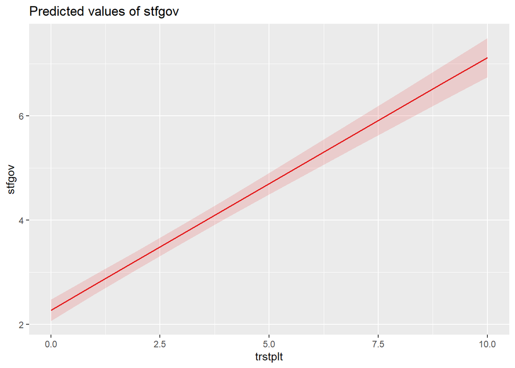

```r
plot_model(ad_model, type = 'pred', term = 'trstplt')
```

We can see a positive relationship between satisfaction with government and trust to politicians

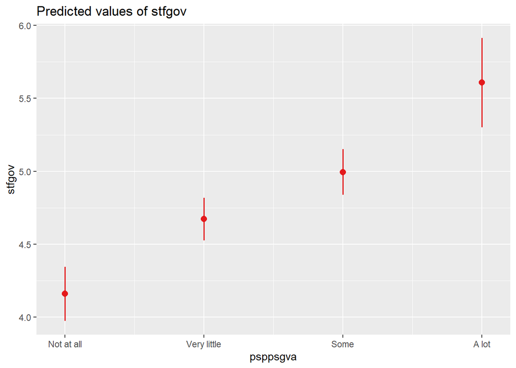

```r
plot_model(ad_model, type = 'pred', term = 'psppsgva')
```

With the growth of political inclusiveness, satisfaction with government increases

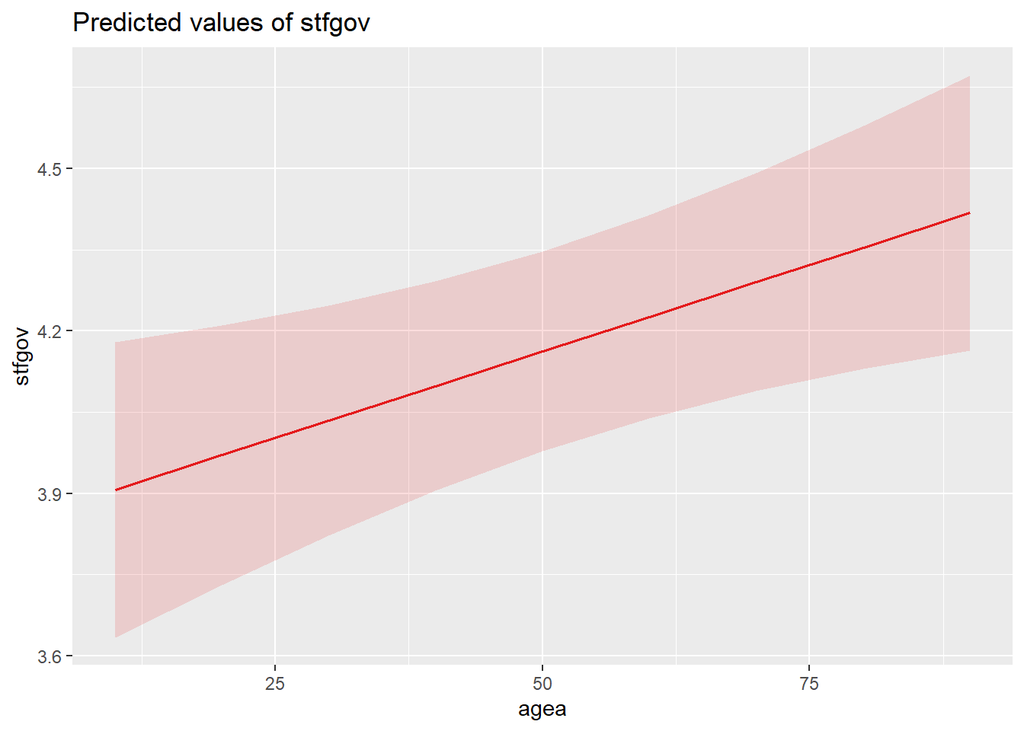

```r
plot_model(ad_model, type = 'pred', term = 'agea')
```

With the growth of respondents age, satisfaction with government increases

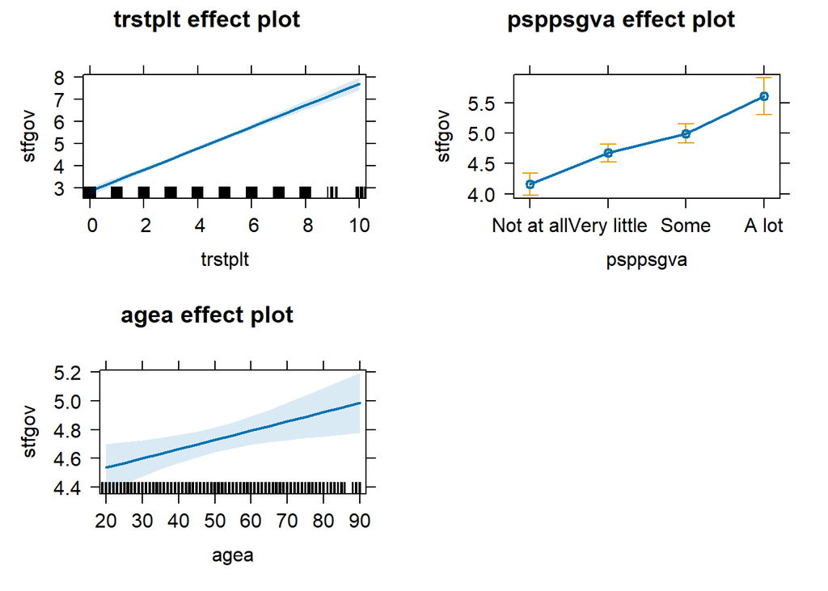

```r
plot(allEffects(ad_model))
```

These plots show the same result but in one facet for better seeing.

## Conclusion:

Summarizing our analysis, we can make several conclusions: 1)We answered our research question and our hypotheses were confirmed. 2)Perceptions of political inclusivity and trust in politicians influence public satisfaction with the national government among French citizens. 3)They also have a positive effect on satisfaction with government. 4) If we conclude our final model in simple terms, then French citizens who are older and trust politicians more and believe that they have higher political inclusion in their state are more satisfied with the national government. We have proven all this by looking at our variables in graphs, building models, and visualizing those models.

# Project 4

Research interest: In addition to exploring the direct relationships between trust in politicians, perceptions of political inclusiveness, and satisfaction with the national government, we aim to investigate whether the relationship between trust in politicians and satisfaction with the national government is moderated by perceptions of political inclusiveness.

Hooghe & Marien (2013) in their study show that the impact of trust in politicians on governmental satisfaction may change based on the level of perceived political inclusiveness. For example, the authors found that political trust and perceptions of inclusiveness interact in shaping citizens’ attitudes towards government performance. When citizens feel included in the political process, their trust in politicians can lead to even higher levels of satisfaction with the government, as they perceive their trust to actually be influential (Hooghe & Marien, 2013).

Moreover, us controlling for age comes from the idea that age is a significant predictor of political attitudes and behaviors. Older individuals tend to have higher satisfaction with government due to more accumulated life experiences and historical contexts that shape their views. For instance, Strate et al. (1989) found that older people often show greater satisfaction with political institutions than younger ones.

References: Hooghe, M., & Marien, S. (2013). How to reach members of parliament? Citizens and modes of access to MPs in Western Europe. Parliamentary Affairs, 66(3), 563-585. Strate, J. M., Parrish, C. J., Elder, C. D., & Ford, C. (1989). Life Span Civic Development and Participation: Socialization of the Middle-aged Citizen. American Political Science Review, 83(1), 285-290.

Research question:How do trust in politicians, age and perceptions of political inclusiveness impact public satisfaction with the national government among French citizens, and how does the relationship between trust in politicians and satisfaction with the national government change with varying levels of perceived political inclusiveness?

Hypotheses: 1.Higher levels of trust in politicians are associated with greater satisfaction with the national government among French citizens. 2.Higher perceived political inclusiveness is associated with higher satisfaction with the national government among French citizens. 3.Higher age of respondent is associated with greater satisfaction with the national government among French citizens. 4.The positive effect of trust in politicians on governmental satisfaction will be stronger among those who perceive higher levels of political inclusiveness.

Justification of variables’ choice: 1.Trust in Politicians (trstplt): this variable is critical as it reflects how reliable and trustworthy French politicians are, which reflects our outcome: how satisfied are people with national governance particularly in a French context where political trust can be unstable and change to a large extent. 2.Perceived Political Inclusiveness (psppsgva): this varible estimates to what extent the political system incorporates public opinion of citizens into decision-making processes,basically how much they feel included and capable to have a say in politics, which we assume would as well impact public’s satisfaction with the national government 3. Age(agea): this is the control variable that we chose in order to see th impacts of other variables on the outcome more accurately

## Interaction model

Let’s build an interaction model

```r
int_model<-lm(stfgov ~ agea + trstplt + psppsgva + trstplt*psppsgva,data = ESS3)
summary(int_model)
```

```
##
## Call:
## lm(formula = stfgov ~ agea + trstplt + psppsgva + trstplt * psppsgva,
##     data = ESS3)
##
## Residuals:
##     Min      1Q  Median      3Q     Max
## -7.6489 -1.2378  0.0819  1.2024  8.1212
##
## Coefficients:
##                              Estimate Std. Error t value Pr(>|t|)
## (Intercept)                  1.761769   0.185585   9.493  < 2e-16 ***
## agea                         0.006500   0.002393   2.716  0.00667 **
## trstplt                      0.562244   0.041925  13.411  < 2e-16 ***
## psppsgvaVery little          0.837417   0.212142   3.947 8.19e-05 ***
## psppsgvaSome                 1.156733   0.257068   4.500 7.22e-06 ***
## psppsgvaA lot                1.824875   0.444374   4.107 4.19e-05 ***
## trstplt:psppsgvaVery little -0.112528   0.056664  -1.986  0.04719 *
## trstplt:psppsgvaSome        -0.104690   0.059878  -1.748  0.08056 .
## trstplt:psppsgvaA lot       -0.112808   0.086136  -1.310  0.19048
## ---
## Signif. codes:  0 '***' 0.001 '**' 0.01 '*' 0.05 '.' 0.1 ' ' 1
##
## Residual standard error: 1.905 on 1864 degrees of freedom
## Multiple R-squared:  0.313,  Adjusted R-squared:  0.3101
## F-statistic: 106.2 on 8 and 1864 DF,  p-value: < 2.2e-16
```

Let’s interpet the results step-by-step:

*Intercept Coefficient:1.761769 This is the expected value of stfgov when all predictors are at their reference levels. p-value<0.05 (highly significant)

*Age (agea) Coefficient: 0.007 For each additional year in age, satisfaction with the national government increases by 0.007 units.This effect is statistically significant (p <0.05), indicating a small but positive relationship between age and government satisfaction. This supports the hypothesis that higher age is associated with greater satisfaction with the national government among French citizens.

*Trust in Politicians (trstplt) Coefficient: 0.562 As trust in politicians increases by one unit, satisfaction with the national government increases by 0.562 units.This relationship is highly significant (p < 0.05). This supports the hypothesis that higher trust in politicians is associated with greater government satisfaction.

*Perceptions of Political Inclusiveness (psppsgva) Perceptions of political inclusiveness have different levels with “Not at all” as the reference category: -Very little: Coefficient: 0.837 When citizens perceive very little political inclusiveness, their satisfaction with the national government increases by 0.837 units compared to those who don’t perceive any inclusiveness at all. This effect is statistically significant (p < 0.05). -Some: Coefficient: 1.157 When citizens perceive some political inclusiveness, their satisfaction with the national government increases by 1.157 units compared to those who who don’t perceive any inclusiveness at all. Statistical Significance: This effect is statistically significant (p < 0.05).

-A lot: Coefficient: 1.825 When citizens perceive a great deal of political inclusiveness, their satisfaction with the national government increases by 1.825 units compared to those who don’t perceive any inclusiveness at all. This effect is statistically significant (p < 0.05).

Interaction Effects:

*Trust in politicians:Very little Coefficient: -0.113 This interaction term suggests that for those perceiving very little political inclusiveness, each unit increase in trust in politicians slightly reduces satisfaction with the national government by 0.113 units. This effect is significant (p <0.05).

*Trustin politicians:Some: Coefficient: -0.105 For those perceiving some political inclusiveness, each unit increase in trust in politicians reduces satisfaction with the national government by 0.105 units. This effect is not significant (p>0.05).

*Trust in politicians:A lot: Coefficient: -0.113 For those perceiving a lot of political inclusiveness, each unit increase in trust in politicians reduces satisfaction with the national government by 0.113 units. This effect is not significant (p >0.05).

Generally, the adjusted R-squared is 0.3101, indicating a good fit for sociological field, adjusting for the number of predictors in the model. The adjusted R-squared for our additive model was 0.3094, which means that our interaction model’s model fit is not much better, just by 0.07%.

## Visualizatoin

Let’s visualise our results:

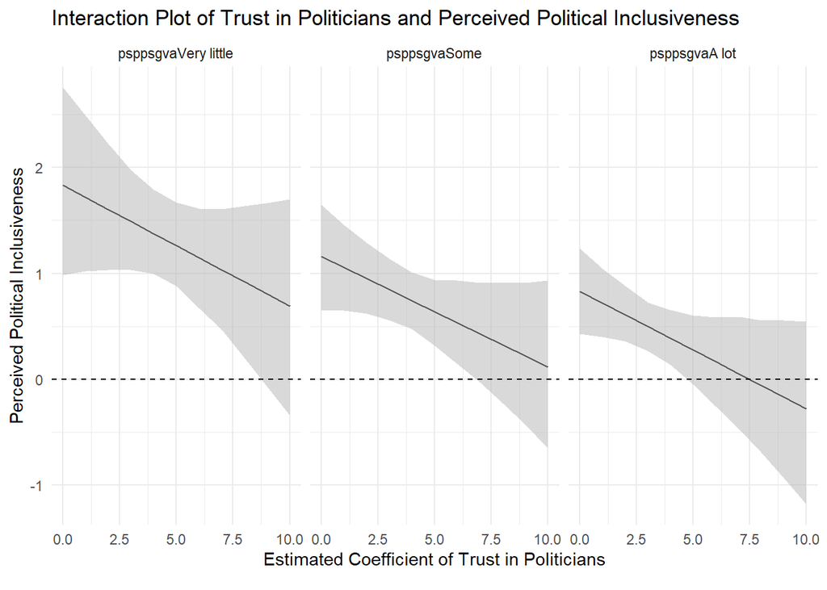

```r
interplot(m = int_model, var1 = "psppsgva", var2 = "trstplt") +
  labs(title = "Interaction Plot of Trust in Politicians and Perceived Political Inclusiveness",
       x = "Estimated Coefficient of Trust in Politicians",
       y = "Perceived Political Inclusiveness") +
  theme_minimal()+
  geom_hline(yintercept = 0, linetype = "dashed")
```

## Comparison of models

Let’s compare additive and interaction models by ANOVA

```r
anova(ad_model, int_model)
```

```
## Analysis of Variance Table
##
## Model 1: stfgov ~ trstplt + psppsgva + agea
## Model 2: stfgov ~ agea + trstplt + psppsgva + trstplt * psppsgva
##   Res.Df    RSS Df Sum of Sq     F Pr(>F)
## 1   1867 6779.4
## 2   1864 6761.7  3    17.717 1.628 0.1809
```

We can see that the RSS of the additive model (6779.4) is higher than RSS of the interaction model (6761.7), which means that the second model is better. However, we have the p-value >0.05 here, which means that adding the interaction terms between trstplt and psppsgva does not significantly improve the model’s fit. However, we have seen significance in one category when looking at the results of our regression model, that’s why we decided to still work with this variable

Let’s build a table to compare additive and interaction models

```r
tab_model(ad_model,int_model,
          dv.labels="Satisfaction with national government",
          pred.labels = c("Intercept","Trust in politicians","Very little perceived political inclusivness","Some perceived political inclusivness","A lot perceived political inclusivness", "Age of respondent", "Trust in politicians: Very little perceived political inclusivness", "Trust in politicians: Some perceived political inclusivness", "Trust in politicians: A lot perceived political inclusivness"))
```

|  | Satisfaction with national government |  |  |  |  |  |
| --- | --- | --- | --- | --- | --- | --- |
| Predictors | Estimates | CI | p | Estimates | CI | p |
| Intercept | 1.96 | 1.64 – 2.28 | **<0.001** | 1.76 | 1.40 – 2.13 | **<0.001** |
| Trust in politicians | 0.48 | 0.44 – 0.53 | **<0.001** | 0.56 | 0.48 – 0.64 | **<0.001** |
| Very little perceived political inclusivness | 0.51 | 0.28 – 0.75 | **<0.001** | 0.84 | 0.42 – 1.25 | **<0.001** |
| Some perceived political inclusivness | 0.84 | 0.58 – 1.09 | **<0.001** | 1.16 | 0.65 – 1.66 | **<0.001** |
| A lot perceived political inclusivness | 1.45 | 1.08 – 1.82 | **<0.001** | 1.82 | 0.95 – 2.70 | **<0.001** |
| Age of respondent | 0.01 | 0.00 – 0.01 | **0.008** | 0.01 | 0.00 – 0.01 | **0.007** |
| Trust in politicians: Very little perceived political inclusivness |  |  |  | -0.11 | -0.22 – -0.00 | **0.047** |
| Trust in politicians: Some perceived political inclusivness |  |  |  | -0.10 | -0.22 – 0.01 | 0.081 |
| Trust in politicians: A lot perceived political inclusivness |  |  |  | -0.11 | -0.28 – 0.06 | 0.190 |
| Observations | 1873 |  |  | 1873 |  |  |
| R<sup>2</sup> / R<sup>2</sup> adjusted | 0.311 / 0.309 |  |  | 0.313 / 0.310 |  |  |

## Conclusions and findings:

1)Confirmation of hypotheses:

1.Higher levels of trust in politicians are associated with greater satisfaction with the national government among French citizens. Confirmed: The coefficient for trust in politicians (0.562, p <0.05) indicates a significant positive relationship between trust in politicians and satisfaction with the national government.

2.Higher perceived political inclusiveness is associated with higher satisfaction with the national government among French citizens. Confirmed: The coefficients for perceived political inclusiveness (“Very little”: 0.837, “Some”: 1.157, “A lot”: 1.825, all p <0.05) show that higher perceived inclusiveness is associated with significantly higher satisfaction.

3.Higher age of respondent is associated with greater satisfaction with the national government among French citizens. Confirmed: The coefficient for age (0.006, p <0.05) indicates a small but significant positive relationship between age and satisfaction with the national government.

2)Findings: